# R Markdown

Alexia Cardona

# RStudio

We will be using RStudio both for this R Markdown session and also during the GitHub session. RStudio is currently a very popular Integrated Development Environment (IDE) for working with R. An IDE is an application used by software developers that faciliates programming by offering source code editing, building and debugging tools all integarated into one application. To function correctly, RStudio needs R and therefore both need to be installed on your computer.

The RStudio Desktop open-source product is free under the [Affero General Public License (AGPL) v3](https://www.gnu.org/licenses/agpl-3.0.en.html). [Other versions of RStudio](https://www.rstudio.com/products/rstudio/) are also available.

We will use RStudio IDE to write code, navigate the files on our computer, inspect the variables we are going to create, and visualize the plots, tables and the notebooks that we will generate. RStudio can also be used for version control and we will be looking at this later on.

[figure not shown]

RStudio interface screenshot. Clockwise from top left: Source, Environment/History, Files/Plots/Packages/Help/Viewer, Console.

RStudio is divided into 4 “Panes”: the **Source** for your scripts and documents (top-left, in the default layout), your **Environment/History/Build/Git** (top-right), your **Files/Plots/Packages/Help/Viewer** (bottom-right), and the R **Console** (bottom-left). The placement of these panes and their content can be customized (see menu, Tools -> Global Options -> Pane Layout).

One of the advantages of using RStudio is that all the information you need to write code is available in a single window. Additionally, with many shortcuts, autocompletion, and highlighting for the major file types you use while developing in R, RStudio will make typing easier and less error-prone.

# Creating an R Markdown project

Before starting to write code in RStudio, we need to create an R Project. The idea behind an R project is to have a workspace where you can keep all the files and settings associated with the project together. In that way, next time you open the R Project it would be easier to resume work. To create an R notebook project for the web in RStudio follow the following steps:

1. `File` -> `New Project` -> `New Directory` -> `Simple Rmarkdown website`.
2. Specify where you would like to create your project. This would be your **working directory**.
3. Click `Create Project`.

RStudio automatically generates a template for you to develop further. To see how this template would look as a website, click on the `Build` tab on the top right hand side pane of RStudio and then click `Build Website`.

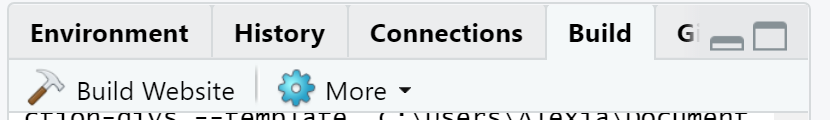

RStudio’s default preferences generally work well, but saving a workspace to `.RData` can be cumbersome, especially if you are working with larger datasets as this would save all the data that is loaded into R into the `.RData` file.  
To turn that off, go to `Tools` -> `Global Options` and select the ‘Never’ option for `Save workspace to .RData' on exit.`

[figure not shown]

Set ‘Save workspace to .RData on exit’ to ‘Never’

## Working directory

Whenever we are working on a project in RStudio, it is good practice to keep a set of related files *e.g.,* data, images, and code, self-contained in a single folder, called the **working directory**. All of the scripts within this folder can then use **relative paths** to files in the working directory that indicate where inside the project a file is located (as opposed to **absolute paths**, which point to where a file is on a specific computer). Working this way makes it a lot easier to move your project around on your computer and share it with others without worrying about whether or not the underlying scripts will still work.

> **Absolute vs Relative paths examples**

> **Relative path**: data/dataset1.txt

> **Absolute path**: C:/Users/User1/Documents/R/my-first-project/**data/dataset1.txt**

Using RStudio projects makes it easy to organise your files in the project and ensures that your working directory is set properly. RStudio shows your current working directory at the top of your window:

[figure not shown]

Another way to check your working directory is by typing `getwd()` in the console pane. If for some reason your working directory is not what it should be, you can change it in the RStudio interface by navigating in the file browser where your working directory should be, and clicking on the blue gear icon `More`, and select `Set As Working Directory`. Alternatively you can type `setwd("/path/to/working/directory")` in the console to reset your working directory (not recommended). However, your scripts should not include this line because it will fail on someone else’s computer.

Using a consistent folder structure across your projects will help keep things organized, and will also make it easy to find things in the future. This can be especially helpful when you have multiple projects. In general, you may create directories (folders) for **data**, and **images**.

- **`data/`** Use this folder to store your raw data and intermediate datasets you may create for the need of a particular analysis. For the sake of transparency and [provenance](https://en.wikipedia.org/wiki/Provenance), you should *always* keep a copy of your raw data accessible and do as much of your data cleanup and preprocessing programmatically (*i.e.,* with scripts, rather than manually). Separating raw data from processed data is also a good idea. For example, you could have files `data/raw/survey.plot1.txt` and `data/raw/survey.plot2.txt` kept separate from a `data_output/survey.csv` file generated by the `scripts/01.preprocess.survey.R` script.
- **`img/`** This would be a place to keep figures that you would like to display in your notebook.
- **`scripts/`** This would be the location to keep your R scripts for different analyses or plotting.

You may want additional directories or subdirectories depending on your project needs, but these should form the backbone of your working directory.

The working directory is an important concept to understand. It is the place from where R will be looking for and saving the files. When you write code for your project, it should refer to files in relation to the root of your working directory and only need files within this structure.

# R Markdown

An R Markdown file is made up of 3 basic components:

- header
- markdown
- R code chunks

In this course we will assume that the output of our report is an .html file. HTML files are files for web pages. This means that the report that we will generate can be easily deployed on the web.

## Header

The markdown document starts with an optional header in YAML format known as the YAML metadata. In the example below the title, author and date are specified in the header. Other options can be specified in the header such as table of content which we will look at later on in the course.

```
---
title: "My first notebook"
author:  Alexia Cardona
date: 18 February 2020
---
```

> **Hint**

> Press the button to see how the report will look like after you make changes to the .Rmd file.

## Markdown

The text following the header in an R Markdown file is in Markdown syntax. This is the syntax that gets converted to HTML format once we click on the Knit button or the Build website button. The philosophy behind Markdown is that it should be easy to write and easy to read.

The full documentation of the Markdown syntax can be found at https://pandoc.org/MANUAL.html. However this can be a bit difficult to follow for beginners, therefore below is a simplified version of the Markdown syntax.

### Headings

Below is the `Markdown code` you need to use to specify headings at different levels and the rendered output respectively below the code:

`# Heading 1`

Heading 1

`## Heading 2`

Heading 2

`### Heading 3`

Heading 3

`#### Heading 4`

Heading 4

### Inline text formatting

To make text **bold** use `**double asterisks**` or `__double underscores__`.  
To make text *italic* use `*asterisks*` or `_underscores_`.  
To make text <sup>superscript</sup> use `^caret^`.  
To make text <sub>subscript</sub> use `~tilde~`.  
To mark text as `inline code` use `` `backticks` ``.  
To strikethrough text use `~~double tilde~~`.

### Line breaks

To create a line break, put more than 2 spaces at the end of a sentence or place `\` in a new line followed by a new line .

### Challenge

> Replicate the output of the text below in R Markdown. The text comes from [a paper by Monya Baker](https://www.nature.com/news/1-500-scientists-lift-the-lid-on-reproducibility-1.19970) that was published in 2016 in the Nature journal that triggered the discussion about Reproducibility Crisis.

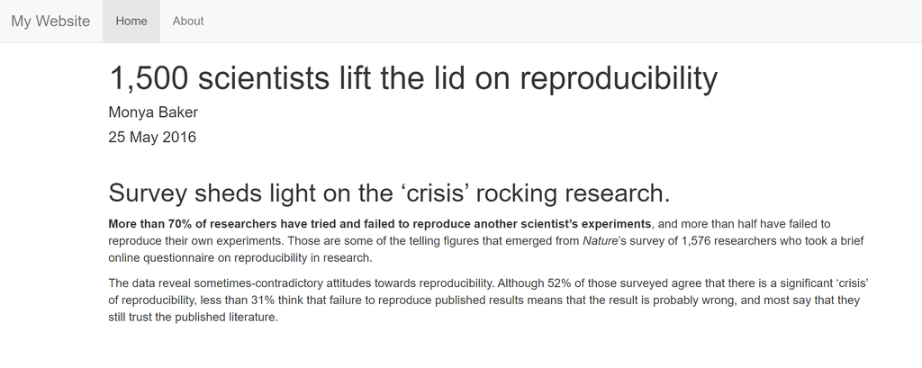

> **Show Answer**

### Links

#### Linking text to Headers

To link text to a header you would need to specify an identification tag next to a header as follows:

`# Markdown {#markdown-header}`

Then to link text to this header use `[link to header](#markdown-header)`. This will be rendered as link to header.

#### Linking text to a webpage

To create a link to a webpage use `[text of link](https://training.cam.ac.uk/bioinformatics/event-timetable)`. This is rendered as [text of link](https://training.cam.ac.uk/bioinformatics/event-timetable).

#### Footnotes

To indicate a footnote use`[^1]` and, for example, indicate another one as`[^2]` and then specify the wordings of the footnotes as:

`[^1]: This is the first footnote.`  
`[^2]: This is the second footnote.`

You do not need to put footnotes at the end of the document for them to be rendered there. This example is rendered as follows:

To indicate a footnote use[^1] and, for example, indicate another one as[^2] and then specify the wordings of the footnotes as:

### Lists

#### Ordered lists

To create an ordered list use the following syntax:

```
1. Item 1
2. Item 2
3. Item 3
```

This is rendered as:

1. Item 1
2. Item 2
3. Item 3

Use 4 spaces to indent an item if you would like to have sub-lists:

```
1. Item 1
2. Item 2
3. Item 3
    a. Item 3a
        i.  Item 3ai
        ii. Item 3aii
    b. Item 3b
    c. Item 3c
4. Item 4
```

1. Item 1
2. Item 2
3. Item 3
   1. Item 3a
      1. Item 3ai
      2. Item 3aii
   2. Item 3b
   3. Item 3c
4. Item 4

#### Unordered lists

In an unordered bulletted list, each item begins with `*`, `+` or `-`. Example:

```
* Item 1
* Item 2
* Item 3
    * Item 3a
        *  Item 3ai
        * Item 3aii
    * Item 3b
    * Item 3c
* Item 4
```

Will be rendered as:

- Item 1
- Item 2
- Item 3
  - Item 3a
    - Item 3ai
    - Item 3aii
  - Item 3b
  - Item 3c
- Item 4

#### Tasks list

Tasks list can be done using the following syntax:

```
- [ ] an unchecked task list item
- [x] checked item
```

This will be rendered as:

- an unchecked task list item
- checked item

### Inserting images

To insert an image use the following syntax: `![Figure caption](path to image)`. Example:

`![R Logo](img/Rlogo.png)`

### Challenge

> **Show Answer**

### Tables

Use `|`and `-` to create a table as follows:

```
| Column 1    | Column 2    |
| ----------- | ----------- |
| Item 1,1    | Item 1,2    |
| Item 2,1    | Item 2,2    |
```

This is rendered as:

| Column 1 | Column 2 |
| --- | --- |
| Item 1,1 | Item 1,2 |
| Item 2,1 | Item 2,2 |

Table alignments can be done using the following syntax:

```
| Left align  | Center align | Right align  |
| :---        |    :----:    |         ---: |
| Item 1,1    | Item 1,2     | Item 1,3     |
| Item 2,1    | Item 2,2     | Item 2,3     |
```

This is rendered as:

| Left align | Center align | Right align |
| --- | --- | --- |
| Item 1,1 | Item 1,2 | Item 1,3 |
| Item 2,1 | Item 2,2 | Item 2,3 |

### Blocks

Blocks in the notebook can be created by using the `>` sign as follows: `> Example of a block`

This is rendered as:

> Example of a block

If you would like to add **code blocks**, use `` ``` `` before and after the code as follows:

````
```
print("Hello world")
x <- 1+2
print(x)
```
````

This will be rendered as:

```
print("Hello world")
x <- 1+2
print(x)
```

### Adding a table of contents

To add a table of contents to your report add the following to the YAML header:

```
output:
  html_document:
    toc: true
    toc_float: true
```

By default all headings up to level 3 headings are displayed in the table of contents. You can adjust this by specifying `toc_depth` as following:

```
output:
  html_document:
    toc: true
    toc_depth: 4
    toc_float: true
```

### (Optional) Adding references

Adding references and citations in Markdown is not as easy as reference manager software such as Mendeley. To be able to create citations you will need to create a bibliography file with all the references in it. Here is an example of a bibliography file. The bibligraphy file has to be placed in the same folder as the one where the `.Rmd` file is. Next, add the following to the YAML header:

```
bibliography: references.bib
link-citations: yes
```

Your YAML header should now look like:

```
---
title: "My first notebook"
author:  Alexia Cardona
date: 18 February 2020
bibliography: references.bib
link-citations: yes
---
```

To cite a reference use the `@` together with the ID of the reference. Example:

`Citation to my paper @cardona2014 and @cardona2019`

To add the bibliography at the end of the report add a References heading at the end of the report:

`# References`

See references at the end of the report.

See https://rmarkdown.rstudio.com/authoring_bibliographies_and_citations.html for more information.

## Inserting R Code in Markdown

So far we have not used any R code and all the code we used so far is in Markdown. As the name suggests, R Markdown files contain Markdown and R. R Markdown files have a `.Rmd` extension. Using R in a Markdown document is useful if we want dynamically generated information such as integrating our analysis in our report. Some operations that we might need to do are; loading our dataset, performing some operations on the dataset and displaying results, either in a table or in a plot. We will be exploring how we can integrate R code in R Markdown in the following worked example.

> 1. Create a new R Markdown document (`File` -> `New File` -> `R Markdown` )
> 2. The file created should already contain some R Markdown code and it should look like this:

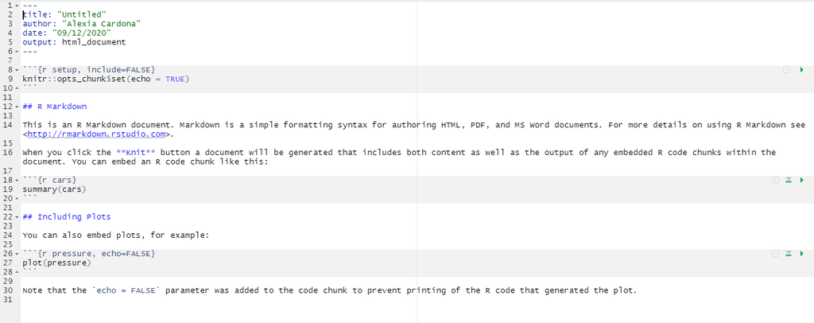

> 3. Delete the existing code leaving only the R Markdown header so that we can start building our code as we go over the worked example.
> 4. Name your R Markdown document as RNotebookExample.Rmd

### The dataset

Our worked example uses data from [gapminder](https://www.gapminder.org/). Let us download the `gapminder_data.csv` dataset into our project. Create a `data` folder in your working directory. Download the dataset into the `data` folder as follows:

```
download.file(url="https://raw.githubusercontent.com/cambiotraining/reproducibility-training/master/data/gapminder_data.csv", destfile="data/gapminder_data.csv")
```

The `gapminder_data.csv` dataset that is loaded into the notebook contains the life expectancy and GDP per capita data for each country per year from 1952 to 2007. The dataset has the following columns:

| Column | Description |
| --- | --- |
| country | Country |
| year | Year the life expectency and GDP per capita index applies |
| pop | Population size |
| continent | Continent |
| lifeExp | Life expectancy |
| gdpPercap | GDP per capita index |

The dataset contains data for different countries in the world. For our analysis we would like to look at only the European countries in the dataset. This means that we would need to manipulate the dataset before we can display the results.

### R code chunks

To be able to insert R code inside a notebook you will have to insert it inside an R code chunk to be able to execute it. To do this either click on the `Insert` button at the top of the Source panel in RStudio:

[figure not shown]

This creates an **R code chunk** as follows:

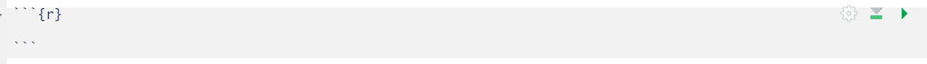

Alternatively, you can type the r code chunk. The R code should be placed in between the triple backticks. Note that on the right hand side of the R code chunk there is a green “play” button that will run the R code chunk if pressed. By default, when the R Markdown document is knitted, the R code will be executed and the R code chunk is displayed before the executed code.

### Chunk options

As mentioned, by default the chunk output will be displayed exactly after the R code chunk and the R code chunk is also displayed in the rendered page. If you would like to have different settings, you can specify these as arguments in the `{}` part of the R code chunk.

These chunk options include:

- `include = FALSE` do not display the code and results in the page after it is knitted. The R code however still runs and therefore the variables or results in this code chunk can be used by the other chunks.
- `echo = FALSE` does not display the code, but it displays the results in the rendered file.
- `message = FALSE` does not display any messages that are generated by the code chunk in the rendered file.
- `warning = FALSE` does not display warnings that are generated by code chunk in the rendered file.

A full list of options that can be used in the R code chunks is found [here](https://www.rstudio.com/wp-content/uploads/2015/03/rmarkdown-reference.pdf).

### Chunk label

Most likely you will specify several R code chunks in your R Markdown file. It is recommended practice to label each R code chunk. This will also help navigating your code easily. At the bottom right of your RStudio you should see the code navigator where you can navigate the different code chunks:

[figure not shown]

To label your chunk just add a label next to `r` in your R code chunk as follows:

````markdown
```{r label-name}
```
````

For our worked example, create an R code chunk and name it as `load-data` and add the following code into your first chunk:

````markdown
```{r load-data}
#load tidyverse library
library(tidyverse) # used for data manipulation
library(rmarkdown) # used for paged_table function
library(kableExtra) # used for table
library(ggpubr) #used for ggarrange function

#read file into R
pop_data <- read_csv("data/gapminder_data.csv")

#create a table with data from European countries in 2007 showing the countries
#with the largest life expectancy at the top
euro_data_tbl <- pop_data %>%
                    filter(continent == "Europe" & year == 2007) %>%
                    select(-continent, -year) %>%
                    arrange(desc(lifeExp)) %>%
                    rename(Country = country, "Population Size" = pop,
                      "Life Expectancy" = lifeExp, "GDP" = gdpPercap)

```
````

We will look at some functions present in the `rmarkdown` and `kableExtra` packages later on. Knit the `RNotebookExample.Rmd` file and see what happens. You may notice that both the code and the output that you would expect to be printed in the console when you run the code are printed in the notebook. We would like to have only the code printed in the notebook. To do that we need to specify the `message=FALSE` as the chunk option for our `load-data` chunk as discussed previously in the chunk options section.

````markdown
```{r load-data, message=FALSE}
````

If you knit `RNotebookExample.Rmd` again you will see that now only the code is being printed, which is what we wanted. In the `load-data` R code chunk, we have loaded the packages we will be using in our report and also the data we will be working with. We then filtered our dataset to contain data from only European countries in 2007 ordered by life expectancy. The next step is to display this filtered dataset that is saved in the variable `eur_data_tbl` in a table.

### Tables in R Markdown

When you have a large dataset, creating a table manually in R Markdown as we did here is not really feasible. Also if you are really trying to make your research reproducible, then, you will need to generate most of the tables dynamically and therefore you will not be able to manually type them in markdown. This is where R Markdown comes in as there is a way to display tables dynamically. In this course we will look at two ways of displaying tables dynamically, using the functions:

1. `kbl()`
2. `paged_table()`

#### `kbl()`

The function `kbl()` is present in the package `kableExtra`, a popular package to display tables in R Markdown. There is extensive documentation on how you can use the functions within the `kableExtra` package to draw tables [here](https://cran.r-project.org/web/packages/kableExtra/vignettes/awesome_table_in_html.html) which has good examples on how to change the different settings of a table, such as font, width, highlights, *etc…*

As a first step, to draw a table you need to use the function `kbl()`. The `kbl()` function takes as an input the dataset you want to display in a table, *e.g.,* `kbl(euro_data_tbl)`.

We have already loaded the package `kableExtra` in the `load-data` R code chunk. Create a new R code chunk called `kbl-table` and draw the a table with the `eur_data_tbl` tibble.

````markdown
```{r kbl}
euro_data_tbl %>%
          kbl()
```
````

Let us add a style to the table so that it looks more attractive. The `kable_styling()` function is the function used to customise the way the table looks. We are going to add the `striped` style so that the table have striped rows and also the `hover` style so that when you move your mouse over the table you can see it hover.

````markdown
```{r kbl}
euro_data_tbl %>%
          kbl() %>%
          kable_styling(bootstrap_options = c("striped", "hover")) %>%
```
````

#### `paged_table()`

If you have a very long table to display, the best way would be to use pagination where the contents of the table are split into multiple tabs. The function `paged_table` in the `rmarkdown` library can be used to do this. It is also very simple to use.

Create a new R code chunk called `paged-table` and use the `paged_table()` function to display the euro_data_tbl table as follows:

````markdown
```{r paged-table}
paged_table(euro_data_tbl)
```
````

### Adding images

Adding images is straightforward and does not require using a specific R Markdown function.

#### Challenge

> Create a new dataset `euro_data_fig` by filtering the `pop_data` tibble to contain only data from Europe. Draw a plot to display the `lifeExp` on the y axis and `year` on the x axis. Use `geom_violin()` to draw this as a violin plot to show the distrubution of the data across each year and save it in a `euro_plot` variable.

> Link to Answer

### Optional

In reports or publications, sometimes you would need to place two or more figures next to each other. `ggarrage()` is a function present in the `ggpubr` pacakge that can help with this. The `ggarrange()` function takes as an input the list of plots to plot. You can specify the number of columns and rows to plot by the ncol and nrow arguments respectively. Another thing that you might need is a lable for each plot so that you can specify the description in your caption. Use the labels argument to specify labels.

### Challenge

> Create a new dataset `uk_data_fig` by filtering the `pop_data` tibble to contain only data from the United Kingdom. Draw a scatter plot to display the `lifeExp` on the y axis and `year` on the x axis and save it in a `uk_plot` variable.  
> Draw the `euro_plot` created in the previous challenge next to a `uk_plot` using the `ggarrange()` function. Label the plots A and B respectively.

> Link to Answer

# Summary

Through R notebooks we can now integrate our R code and our results in one readable document that we can share with our collaborators. In this way the code and the results have become one item. For inspiration, examples of R notebooks can be found at https://rpubs.com/

# References

Cardona, Alexia, Felix R. Day, John R. B. Perry, Marie Loh, Audrey Y. Chu, Benjamin Lehne, Dirk S. Paul, et al. 2019. “Epigenome-Wide Association Study of Incident Type 2 Diabetes in a British Population: EPIC-Norfolk Study.” *Diabetes*. https://doi.org/10.2337/db18-0290.

[^1]: This is the first footnote.
[^2]: This is the second footnote.